# Laboratorio Analisis Exploratorio

Dilary Cruz, Alexander de la Cruz, Daniel Juárez

2026-02-02

### Repositorio

https://github.com/djuarez-2017510/Lab1-MineriaDatos

# PUNTO 1

### Dimensiones del conjunto de datos

El conjunto de datos contiene 19,883 observaciones (películas) y 28 variables.

### Estructura de los datos

El dataset incluye variables cuantitativas y cualitativas, relacionadas con presupuesto, ingresos, duración, popularidad, género, elenco y características de producción.

### Resumen estadístico general

El resumen estadístico permite observar medidas descriptivas de las variables cuantitativas, así como la presencia de valores cero en variables financieras y de votación, lo cual indica que no todas las películas cuentan con esta información disponible.

### Valores faltantes

Se identificó que algunas variables no cuentan con información completa para todas las películas, lo cual es común en conjuntos de datos reales y deberá considerarse en análisis posteriores.

### Vista preliminar del conjunto de datos

Las primeras filas permiten verificar que los datos fueron cargados correctamente y observar la estructura general de las variables.

### Tabla

Resumen general del conjunto de datos

| Caracteristica | Descripcion |
| --- | --- |
| Número de observaciones | 19,883 películas |
| Número de variables | 28 variables |
| Variables cuantitativas | budget, revenue, runtime, popularity, voteAvg, voteCount, genresAmount, productionCoAmount, productionCountriesAmount, actorsAmount, castWomenAmount, castMenAmount, releaseYear |
| Variables cualitativas | genres, homePage, productionCompany, productionCompanyCountry, productionCountry, director, actors, actorsPopularity, actorsCharacter, originalTitle, title, originalLanguage, releaseDate |
| Valores faltantes | Algunas películas no cuentan con información completa en todas las variables |

El conjunto de datos analizado contiene 19,883 películas y 28 variables. Dentro de las variables cuantitativas se incluye el campo id, el cual se utiliza únicamente como identificador de cada película y no como una variable de análisis. El dataset también contiene variables cuantitativas relacionadas con presupuesto, ingresos, duración y calificaciones, así como variables cualitativas que describen características como género, idioma, país de producción y elenco. Esta exploración permitió obtener una visión general de la estructura del conjunto de datos.

# PUNTO 2

Clasificación de las variables del conjunto de datos

[output not shown]

# PUNTO 3

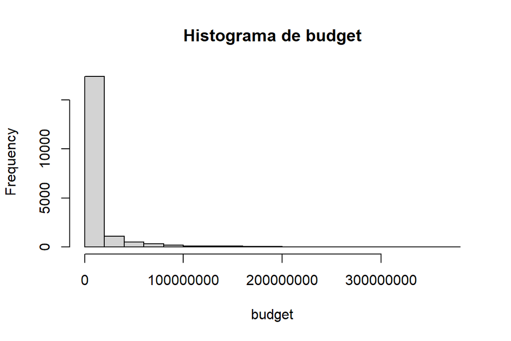

```
##
## Variable: budget
##
##  Lilliefors (Kolmogorov-Smirnov) normality test
##
## data:  x
## D = 0.37204, p-value < 0.00000000000000022
##
## ➡ La variable budget NO sigue una distribución normal.
```

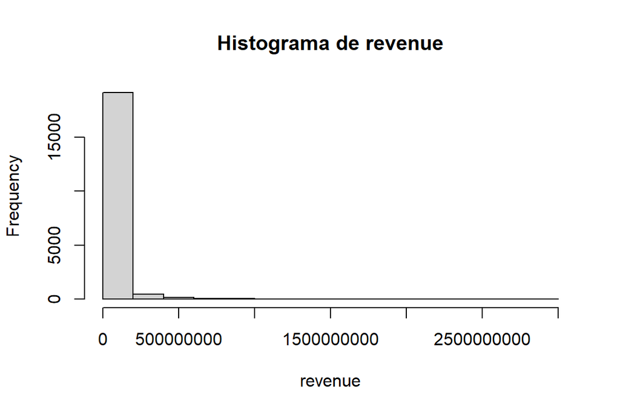

```
##
## Variable: revenue
##
##  Lilliefors (Kolmogorov-Smirnov) normality test
##
## data:  x
## D = 0.39765, p-value < 0.00000000000000022
##
## ➡ La variable revenue NO sigue una distribución normal.
```

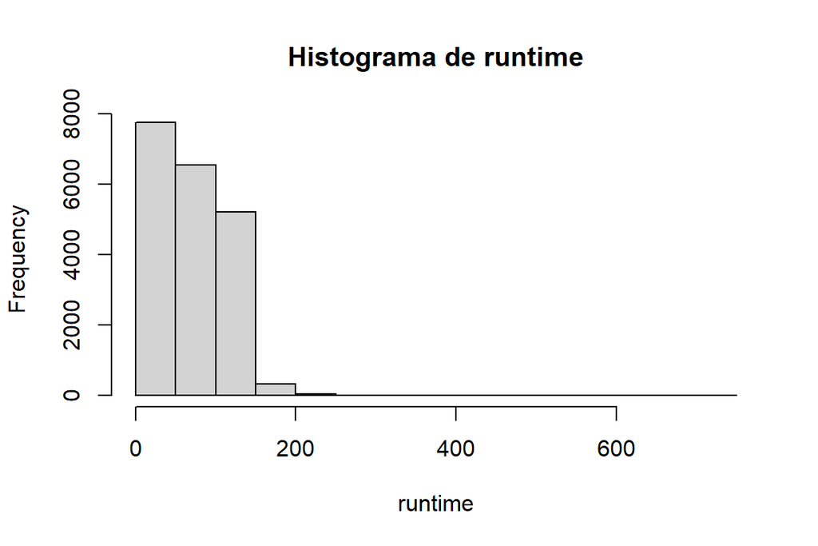

```
##
## Variable: runtime
##
##  Lilliefors (Kolmogorov-Smirnov) normality test
##
## data:  x
## D = 0.1629, p-value < 0.00000000000000022
##
## ➡ La variable runtime NO sigue una distribución normal.
```

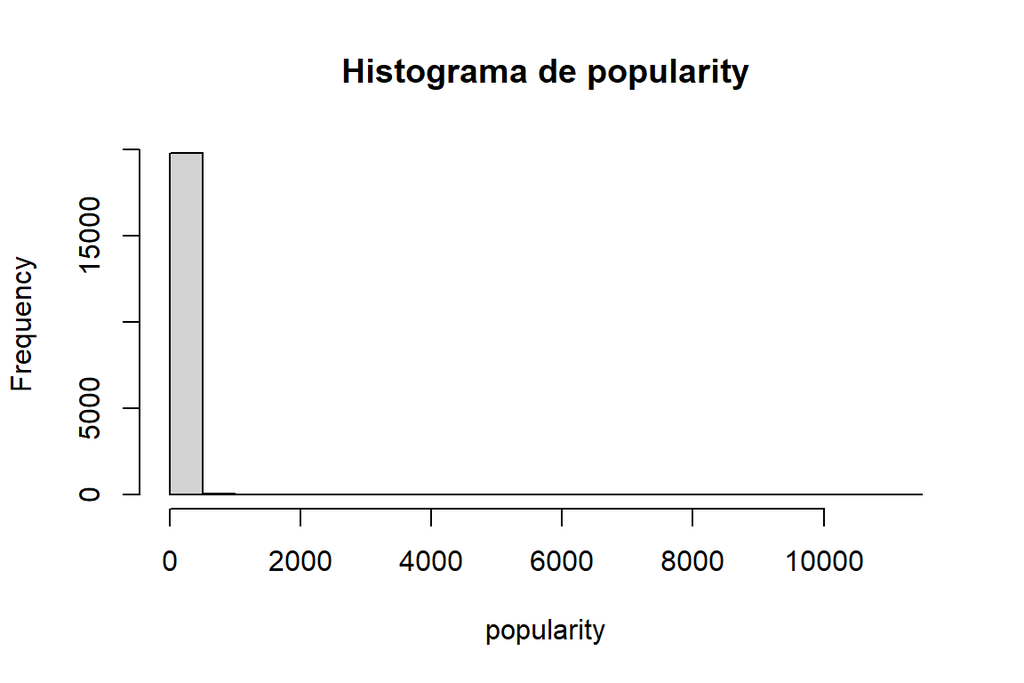

```
##
## Variable: popularity
##
##  Lilliefors (Kolmogorov-Smirnov) normality test
##
## data:  x
## D = 0.43322, p-value < 0.00000000000000022
##
## ➡ La variable popularity NO sigue una distribución normal.
```

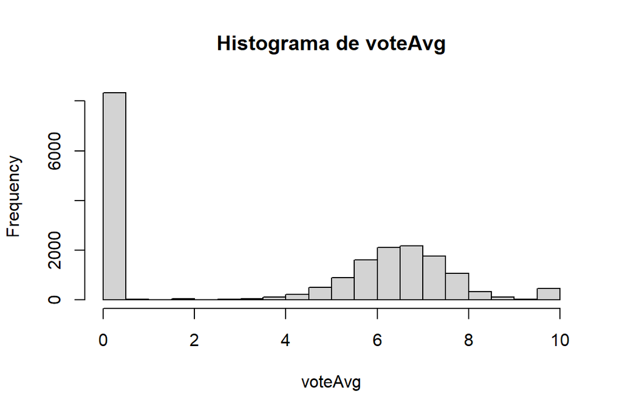

```
##
## Variable: voteAvg
##
##  Lilliefors (Kolmogorov-Smirnov) normality test
##
## data:  x
## D = 0.28937, p-value < 0.00000000000000022
##
## ➡ La variable voteAvg NO sigue una distribución normal.
```

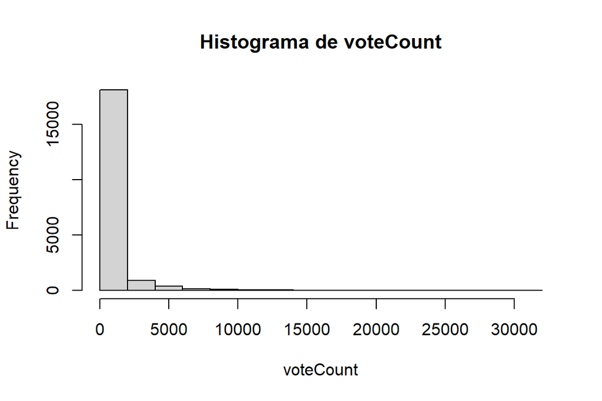

```
##
## Variable: voteCount
##
##  Lilliefors (Kolmogorov-Smirnov) normality test
##
## data:  x
## D = 0.36364, p-value < 0.00000000000000022
##
## ➡ La variable voteCount NO sigue una distribución normal.
```

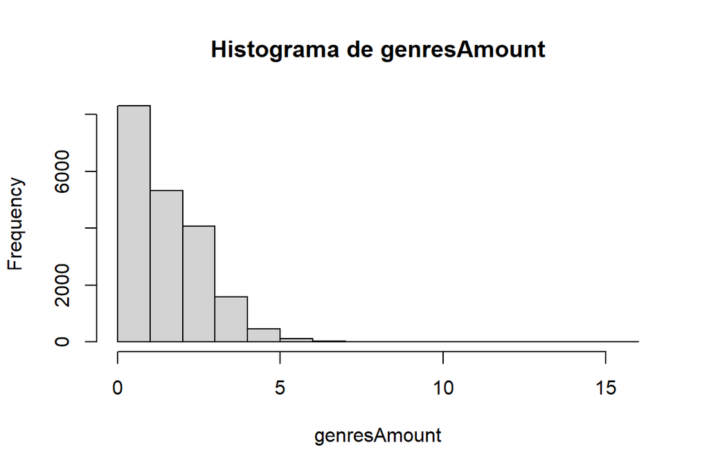

```
##
## Variable: genresAmount
##
##  Lilliefors (Kolmogorov-Smirnov) normality test
##
## data:  x
## D = 0.19266, p-value < 0.00000000000000022
##
## ➡ La variable genresAmount NO sigue una distribución normal.
```

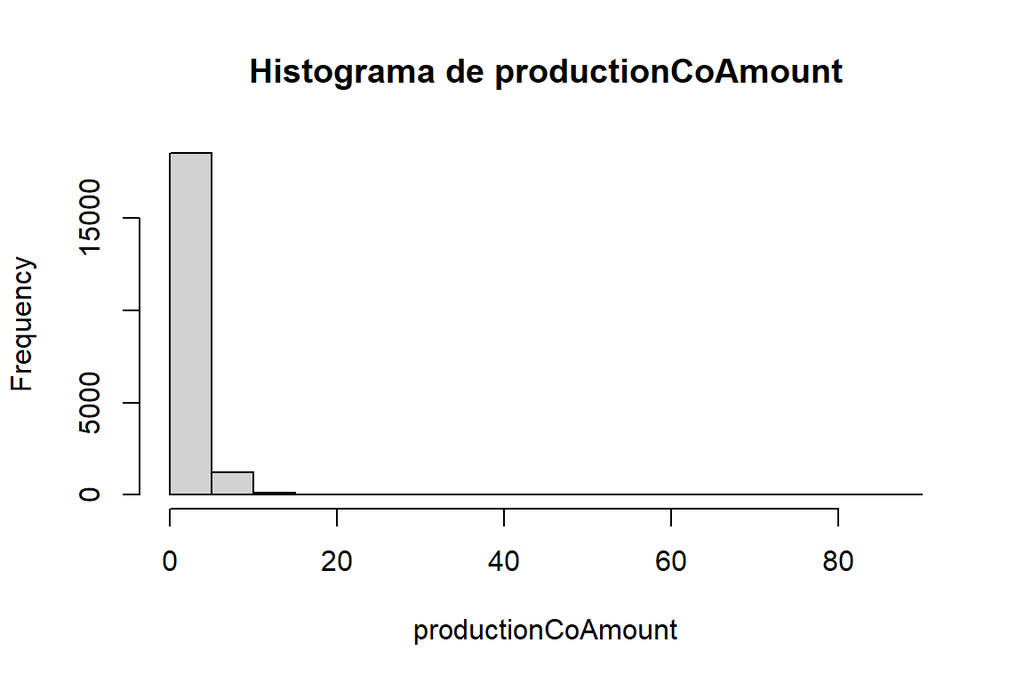

```
##
## Variable: productionCoAmount
##
##  Lilliefors (Kolmogorov-Smirnov) normality test
##
## data:  x
## D = 0.20818, p-value < 0.00000000000000022
##
## ➡ La variable productionCoAmount NO sigue una distribución normal.
```

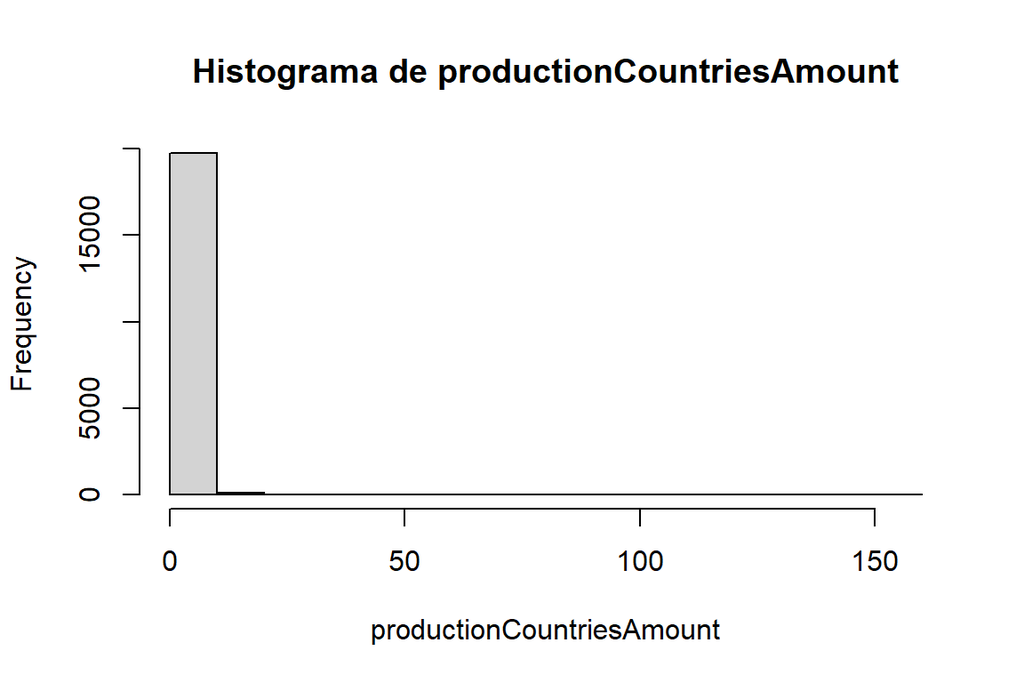

```
##
## Variable: productionCountriesAmount
##
##  Lilliefors (Kolmogorov-Smirnov) normality test
##
## data:  x
## D = 0.3698, p-value < 0.00000000000000022
##
## ➡ La variable productionCountriesAmount NO sigue una distribución normal.
```

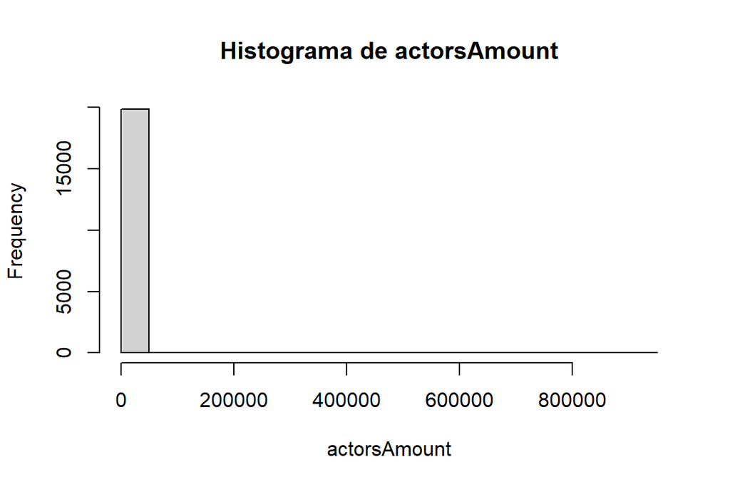

```
##
## Variable: actorsAmount
##
##  Lilliefors (Kolmogorov-Smirnov) normality test
##
## data:  x
## D = 0.51124, p-value < 0.00000000000000022
##
## ➡ La variable actorsAmount NO sigue una distribución normal.
```

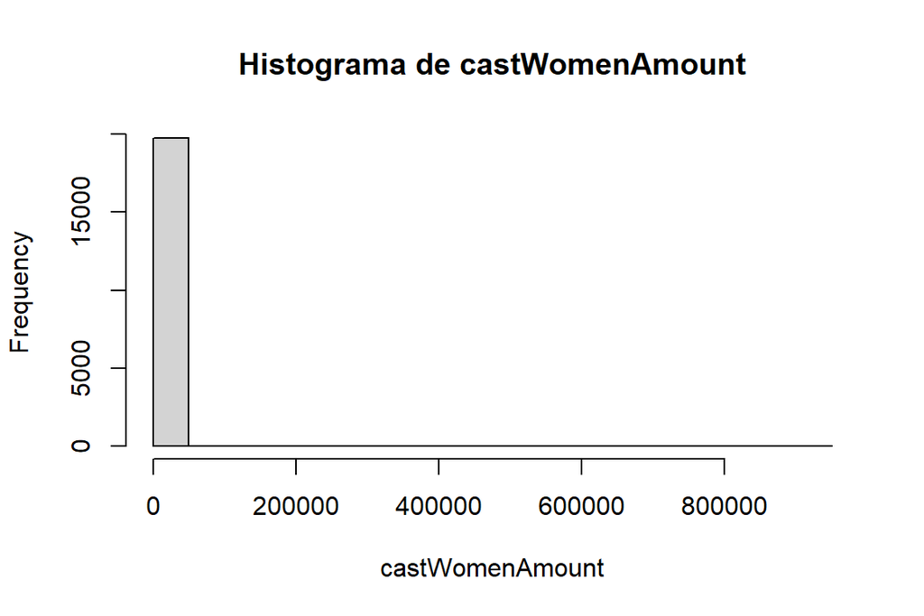

```
##
## Variable: castWomenAmount
##
##  Lilliefors (Kolmogorov-Smirnov) normality test
##
## data:  x
## D = 0.52228, p-value < 0.00000000000000022
##
## ➡ La variable castWomenAmount NO sigue una distribución normal.
```

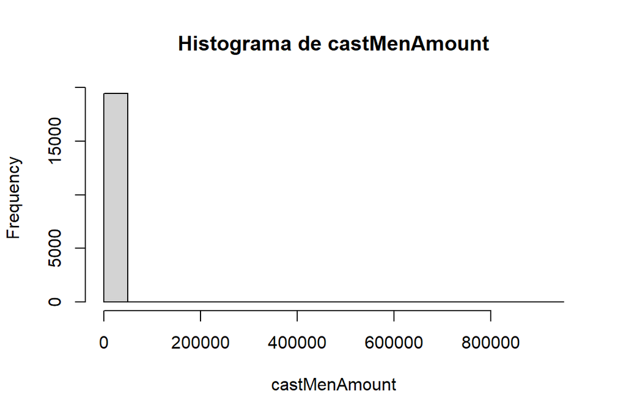

```
##
## Variable: castMenAmount
##
##  Lilliefors (Kolmogorov-Smirnov) normality test
##
## data:  x
## D = 0.52698, p-value < 0.00000000000000022
##
## ➡ La variable castMenAmount NO sigue una distribución normal.
```

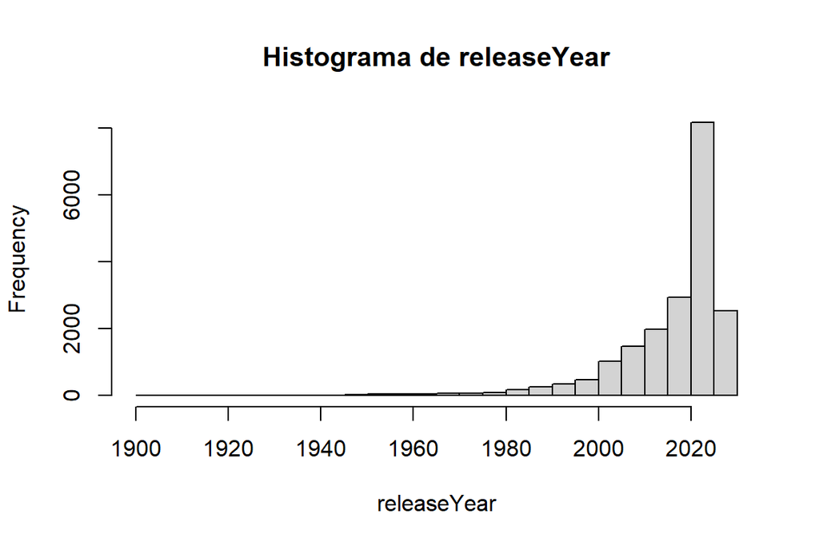

```
##
## Variable: releaseYear
##
##  Lilliefors (Kolmogorov-Smirnov) normality test
##
## data:  x
## D = 0.23746, p-value < 0.00000000000000022
##
## ➡ La variable releaseYear NO sigue una distribución normal.
```

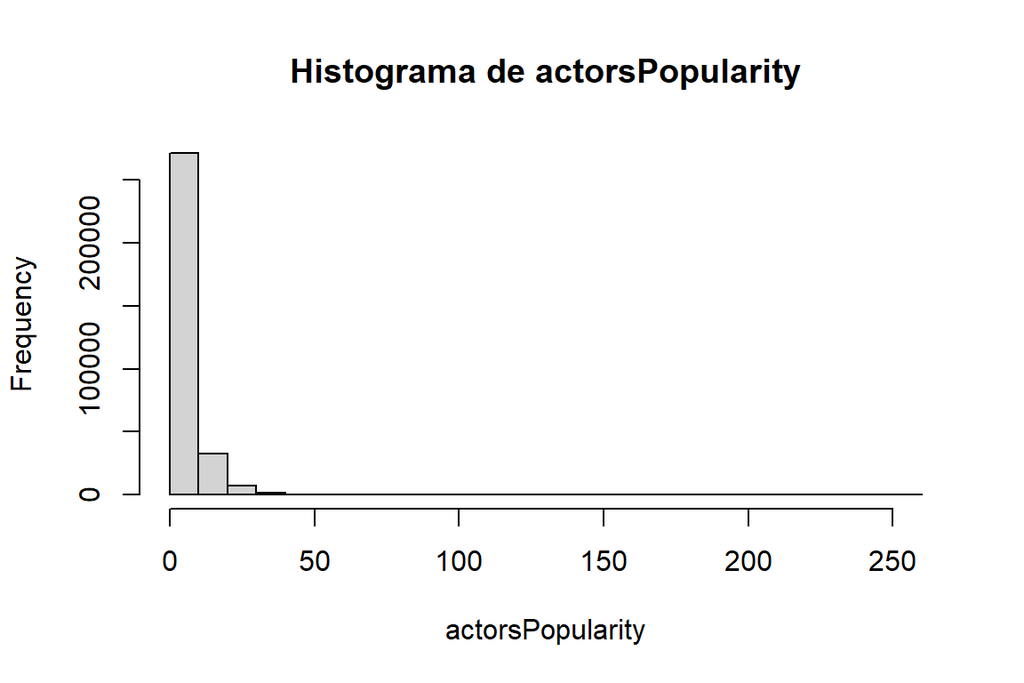

```
##
## Variable: actorsPopularity
##
##  Lilliefors (Kolmogorov-Smirnov) normality test
##
## data:  x
## D = 0.25719, p-value < 0.00000000000000022
##
## ➡ La variable actorsPopularity NO sigue una distribución normal.
```

```
##
##
## Table: Frecuencia Completa - Géneros
##
## |genres          |    n|
## |:---------------|----:|
## |Drama           | 6561|
## |Comedy          | 4796|
## |Thriller        | 3384|
## |Action          | 3041|
## |Documentary     | 2432|
## |Horror          | 2404|
## |Adventure       | 2005|
## |Romance         | 2001|
## |Animation       | 1980|
## |Family          | 1741|
## |Fantasy         | 1641|
## |Crime           | 1559|
## |Science Fiction | 1556|
## |Mystery         | 1228|
## |Music           |  789|
## |History         |  572|
## |TV Movie        |  444|
## |War             |  343|
## |Western         |  166|
```

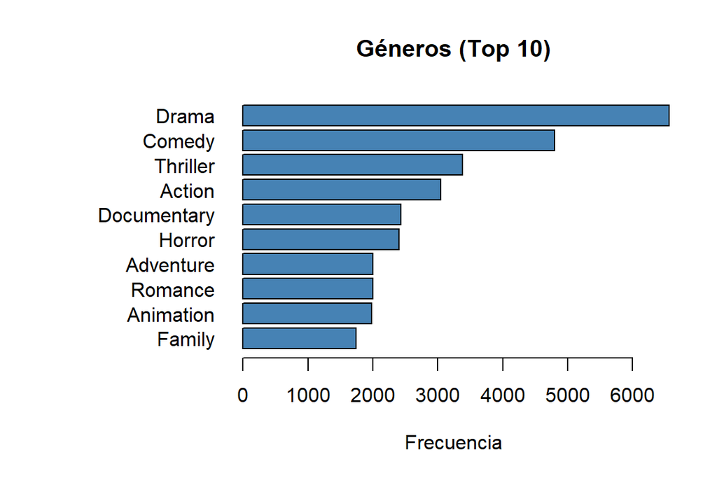

```
##
##
## Table: Frecuencia Completa - Idioma Original
##
## |originalLanguage |     n|
## |:----------------|-----:|
## |en               | 11961|
## |es               |  1238|
## |fr               |  1094|
## |ja               |   868|
## |pt               |   628|
## |de               |   461|
## |zh               |   365|
## |ko               |   336|
## |it               |   302|
## |nl               |   192|
## |ru               |   190|
## |id               |   173|
## |sv               |   133|
## |tl               |   110|
## |ar               |   106|
## |tr               |   106|
## |cn               |   100|
## |hi               |   100|
## |da               |    94|
## |xx               |    92|
## |pl               |    80|
## |ta               |    74|
## |fa               |    70|
## |ml               |    59|
## |th               |    59|
## |te               |    57|
## |no               |    54|
## |bn               |    45|
## |fi               |    45|
## |uk               |    43|
## |el               |    39|
## |ca               |    36|
## |cs               |    36|
## |et               |    36|
```

[output cut: 45 more lines]

```
## |mt               |     2|
## |or               |     2|
## |rw               |     2|
## |ab               |     1|
## |be               |     1|
## |ht               |     1|
## |ig               |     1|
## |la               |     1|
## |mo               |     1|
## |qu               |     1|
## |sn               |     1|
## |so               |     1|
## |sw               |     1|
## |xh               |     1|
## |zu               |     1|
```

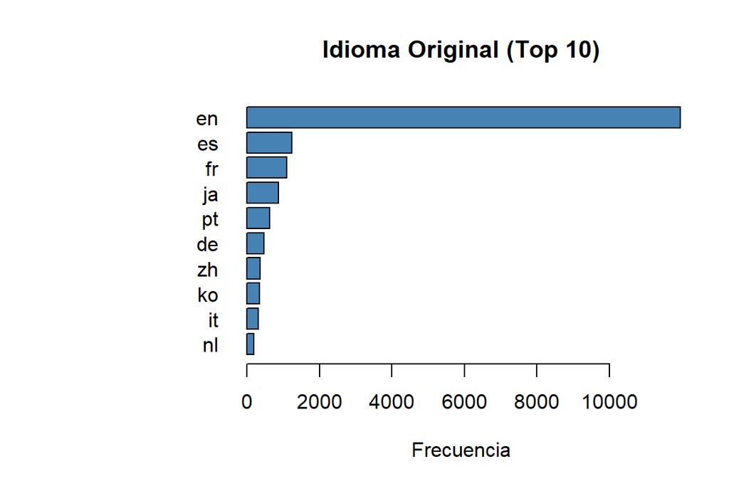

```
##
##
## Table: Frecuencia Completa - Países Productores
##
## |productionCountry        |    n|
## |:------------------------|----:|
## |United States of America | 6783|
## |United Kingdom           | 1171|
## |US                       |  996|
## |Japan                    |  731|
## |France                   |  667|
## |Canada                   |  633|
## |FR                       |  522|
## |Germany                  |  507|
## |GB                       |  440|
## |DE                       |  389|
## |BR                       |  340|
## |IN                       |  330|
## |Spain                    |  281|
## |CA                       |  256|
## |China                    |  231|
## |ES                       |  220|
## |Italy                    |  209|
## |AR                       |  192|
## |Australia                |  188|
## |South Korea              |  183|
## |ID                       |  177|
## |Hong Kong                |  163|
## |KR                       |  163|
## |JP                       |  161|
## |IT                       |  160|
## |Mexico                   |  159|
## |NL                       |  146|
## |Belgium                  |  142|
## |AU                       |  129|
## |MX                       |  128|
## |BE                       |  110|
## |PH                       |   98|
## |RU                       |   85|
## |CN                       |   84|
```

[output cut: 201 more lines]

```
## |NA                       |    1|
## |Namibia                  |    1|
## |Palestinian Territory    |    1|
## |Panama                   |    1|
## |RW                       |    1|
## |SO                       |    1|
## |Slovakia                 |    1|
## |Slovenia                 |    1|
## |Sri Lanka                |    1|
## |TJ                       |    1|
## |Tunisia                  |    1|
## |Vietnam                  |    1|
## |XG                       |    1|
## |YE                       |    1|
## |ZM                       |    1|
```

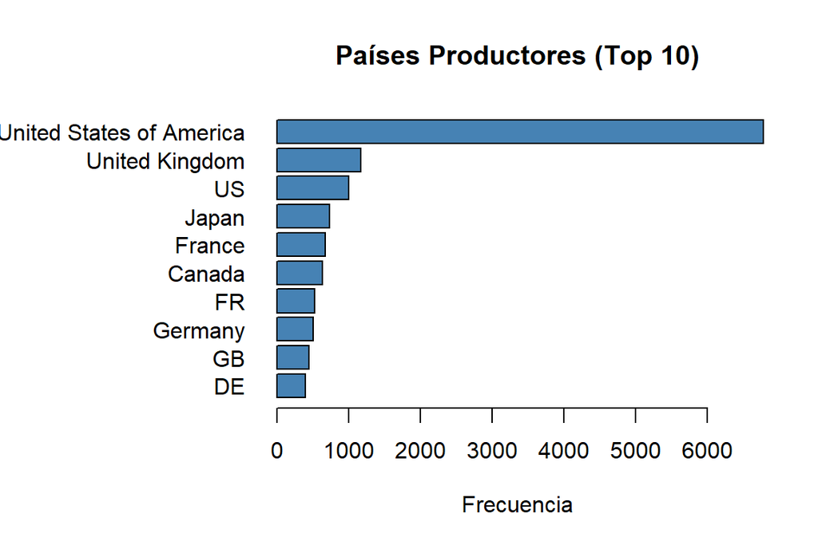

[output not shown]

[output not shown]

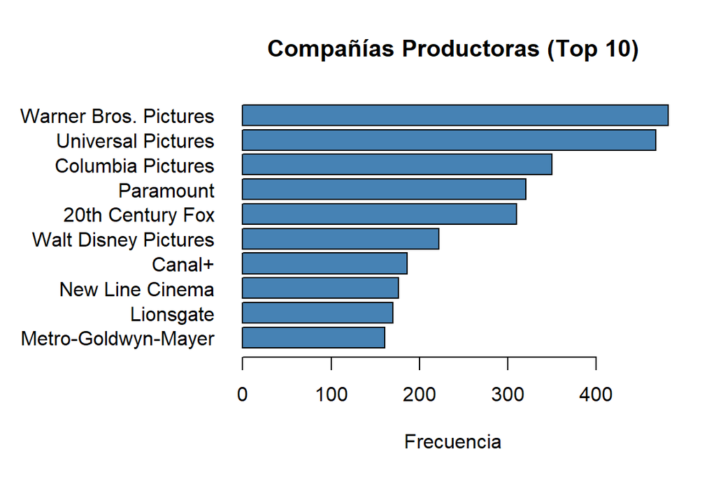

```
##
##
## Table: Frecuencia: ¿Tiene Video?
##
## |Var1  |  Freq|
## |:-----|-----:|
## |FALSE | 19313|
## |TRUE  |    84|
```

### PREGUNTAS

*1. ¿Cuáles son las 10 películas que contaron con más presupuesto?*

```
##                                          title    budget
## 1  Pirates of the Caribbean: On Stranger Tides 380000000
## 2                      Avengers: Age of Ultron 365000000
## 3                            Avengers: Endgame 356000000
## 4                         Avatar: Fire and Ash 350000000
## 5     Pirates of the Caribbean: At World's End 300000000
## 6                               Justice League 300000000
## 7                       Avengers: Infinity War 300000000
## 8                             Superman Returns 270000000
## 9                                      Tangled 260000000
## 10                               The Lion King 260000000
```

*2. ¿Cuáles son las 10 películas que más ingresos tuvieron?*

```
##                           title    revenue
## 1                        Avatar 2847246203
## 2             Avengers: Endgame 2797800564
## 3                       Titanic 2187463944
## 4  Star Wars: The Force Awakens 2068223624
## 5        Avengers: Infinity War 2046239637
## 6                    Zootopia 2 1744338246
## 7                Jurassic World 1671713208
## 8                 The Lion King 1667635327
## 9       Spider-Man: No Way Home 1631853496
## 10                 The Avengers 1518815515
```

*3. ¿Cuál es la película que más votos tuvo?*

```
##       title voteCount
## 1 Inception     30788
```

*4. ¿Cuál es la peor película de acuerdo a los votos de todos los usuarios?*

```
##                  title voteAvg voteCount
## 1 Dragonball Evolution     2.8      1600
```

*5. ¿Cuántas películas se hicieron en cada año?*

```
##     releaseYear    n
## 1          1902    1
## 2          1920    1
## 3          1921    1
## 4          1922    1
## 5          1925    2
## 6          1926    1
## 7          1927    2
## 8          1929    1
## 9          1930    1
## 10         1931    4
## 11         1932    1
## 12         1933    1
## 13         1935    1
## 14         1936    1
```

[output cut: 87 more lines]

*a. ¿En qué año se hicieron más películas?*

```
##   releaseYear    n
## 1        2025 7351
```

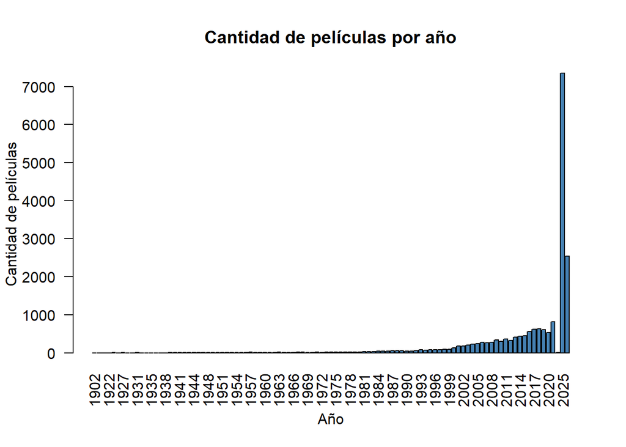

*6. ¿Cuál es el género principal de las 20 películas más recientes?*

```
##   genero_principal n
## 1            Drama 6
## 2           Comedy 4
## 3        Animation 3
## 4         Thriller 3
## 5           Action 1
## 6          Romance 1
## 7              War 1
## 8             <NA> 1
```

*a. ¿Cuál es el género principal que predomina en el conjunto de datos?*

```
##   genero_principal    n
## 1            Drama 3734
## 2           Comedy 2640
## 3      Documentary 2245
## 4             <NA> 1965
## 5           Action 1760
## 6           Horror 1513
```

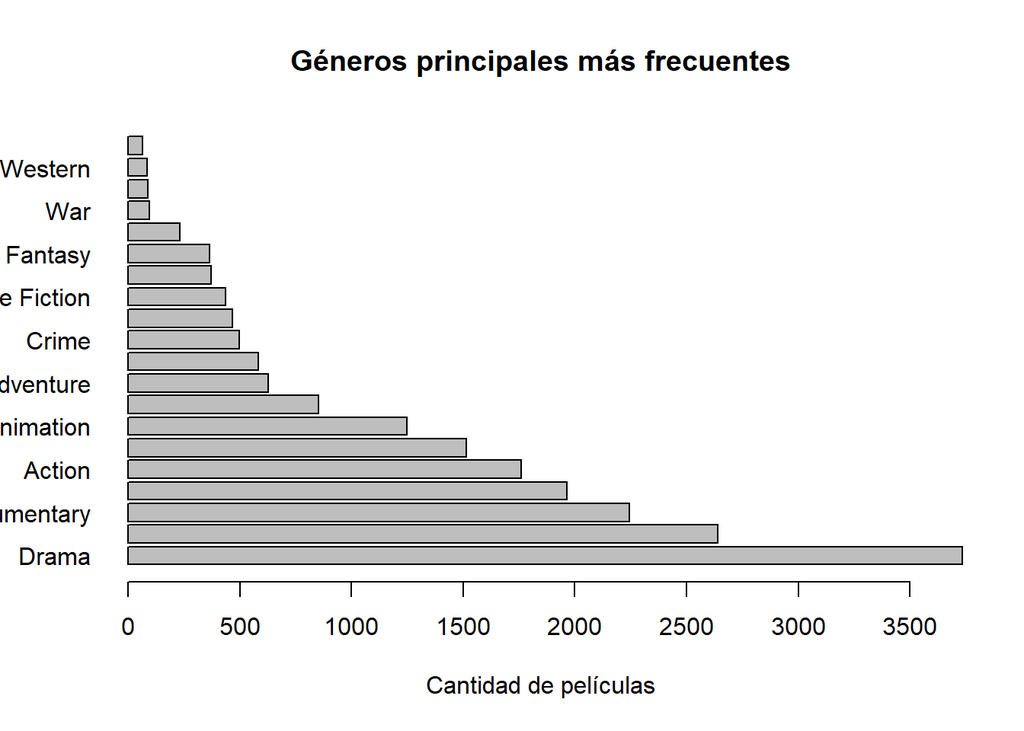

*b. ¿A qué género principal pertenecen las películas más largas?*

```
## # A tibble: 6 × 2
##   genero_principal duracion_promedio
##   <chr>                        <dbl>
## 1 War                          105.
## 2 Action                        99.5
## 3 Adventure                     99.1
## 4 Crime                         95.9
## 5 History                       92.3
## 6 Western                       88.2
```

*7. ¿Las películas de qué género principal obtuvieron mayores ganancias?*

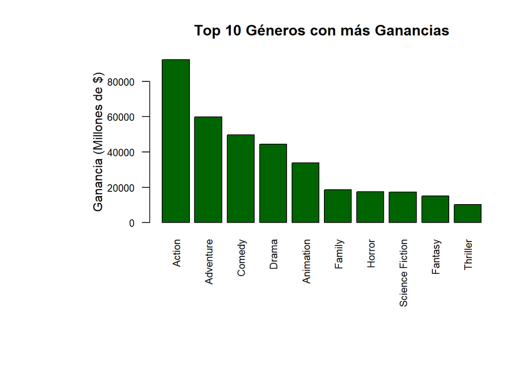

*8. ¿La cantidad de actores influye en los ingresos de las películas? ¿Se han hecho películas con más actores en los últimos años?*

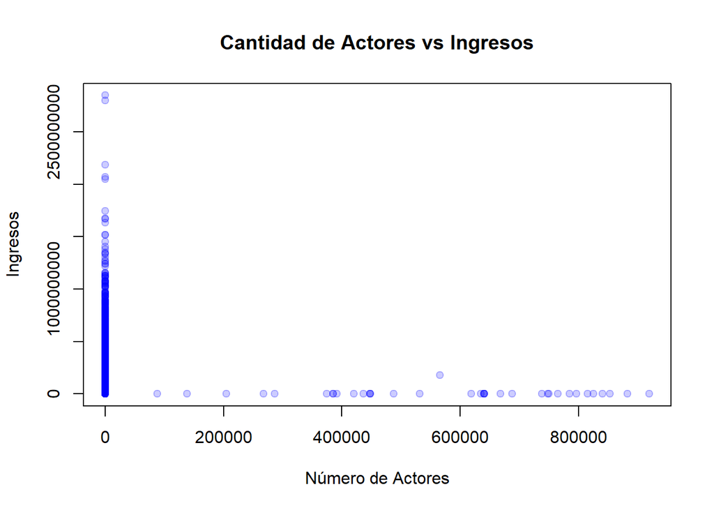

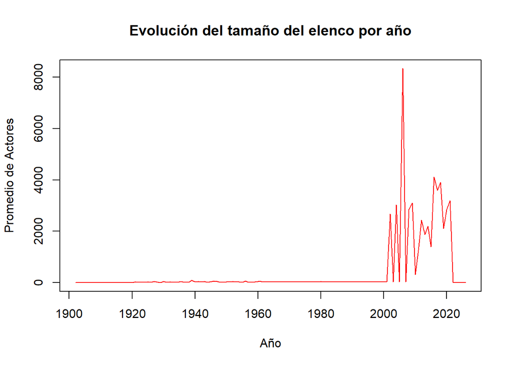

Al ver que la correlación es casi nula no damos cuenta que llenar la película de actores no garantiza vender más entradas. Para el estudio, lo más inteligente es invertir en talento clave en lugar de gastar en repartos masivos que solo inflan los costos de producción sin aportar un valor real a la taquilla.

*9. ¿Es posible que la cantidad de hombres y mujeres en el reparto influya en la popularidad y los ingresos?*

```
##                 Variable Correlacion
## 1 Mujeres vs Popularidad  0.01014426
## 2 Hombres vs Popularidad  0.02151289
## 3    Mujeres vs Ingresos -0.01702516
## 4    Hombres vs Ingresos -0.02727603
```

*10. ¿Quiénes son los directores que hicieron las 20 películas mejor calificadas?*

```
##                                                                                                director
## 1           Kim Nam-joon|Jeon Jung-kook|Kim Tae-hyung|Park Ji-min|Jung Ho-seok|Kim Seok-jin|Min Yoon-gi
## 2                                                                                          Park Jun-soo
## 3                                                                                          Park Jun-soo
## 4                                                                                Carlos P\xe9rez Osorio
## 5                                                                                          Park Jun-soo
## 6                                                                                       Taichi Ishidate
## 7                                                                                         Takahiro Miki
## 8                                                                                              Amp Wong
## 9                                                                                  Francis Ford Coppola
## 10                                                                                       Frank Darabont
## 11                                                                                        Aditya Chopra
## 12 Beyonc\xe9|Mark Romanek|Jonas \xc5kerlund|Kahlil Joseph|Melina Matsoukas|Todd Tourso|Dikayl Rimmasch
## 13                                                                                        Kotaro Tamura
## 14                                                                                 Francis Ford Coppola
```

[output cut: 27 more lines]

*11. ¿Cómo se correlacionan los presupuestos con los ingresos? ¿Los altos presupuestos significan altos ingresos?*

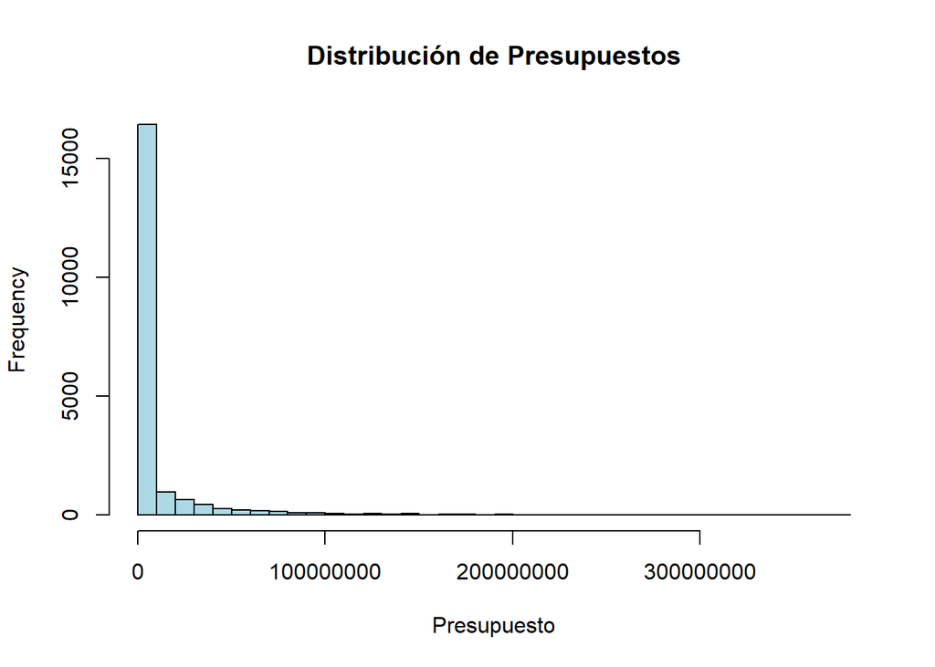

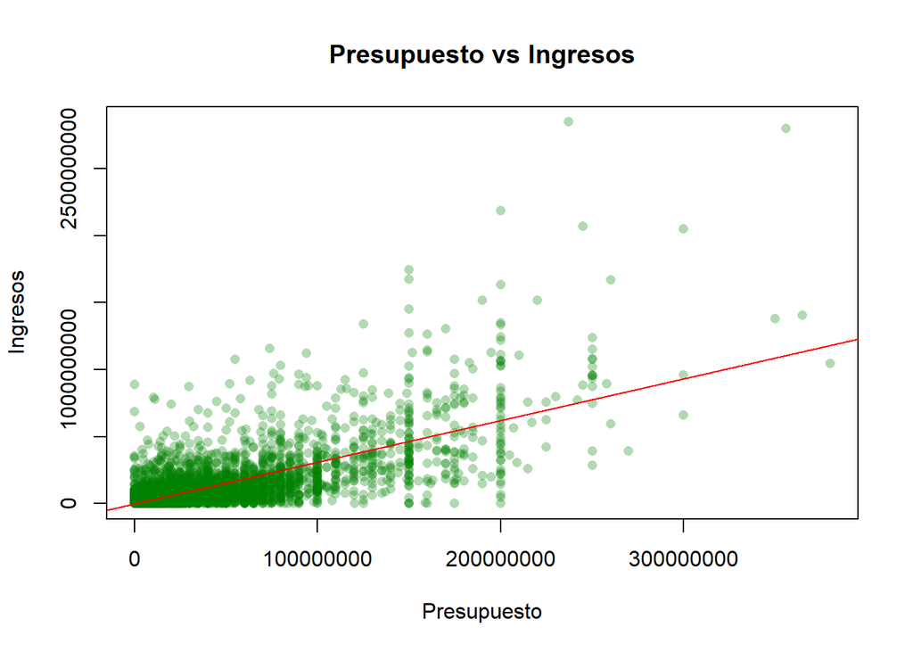

La gráfica confirma que el presupuesto ayuda, pero no es una garantía absoluta de éxito. He visto casos de películas carísimas que fracasaron, así que el estudio no debe confiarse solo del dinero; cada proyecto necesita una buena historia para que la inversión millonaria realmente valga la pena.

*12. ¿Se asocian ciertos meses de lanzamiento con mejores ingresos?*

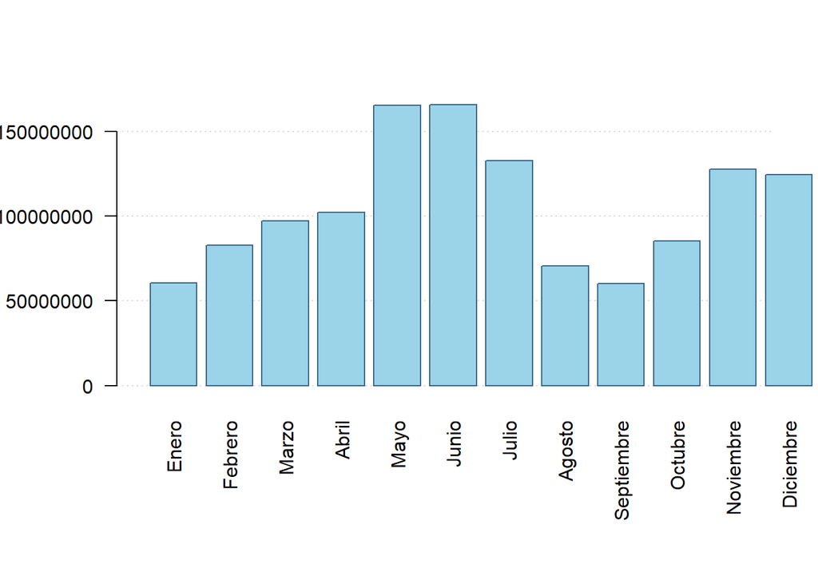

Los resultados muestran que los ingresos promedio de las películas presentan variaciones según el mes de lanzamiento, lo que sugiere que el momento del estreno puede estar asociado con el desempeño económico. Se observa que ciertos meses registran ingresos promedio más altos que otros, lo cual podría estar relacionado con temporadas vacacionales o periodos de mayor asistencia a las salas de cine. No obstante, aunque el mes de estreno parece influir en los ingresos, este factor por sí solo no garantiza el éxito comercial de una película, ya que intervienen otros elementos como el contenido, el elenco y la estrategia de marketing.

*13. ¿En qué meses se han visto los lanzamientos con mejores ingresos? ¿cuantas películas, en promedio, se han lanzado por mes?*

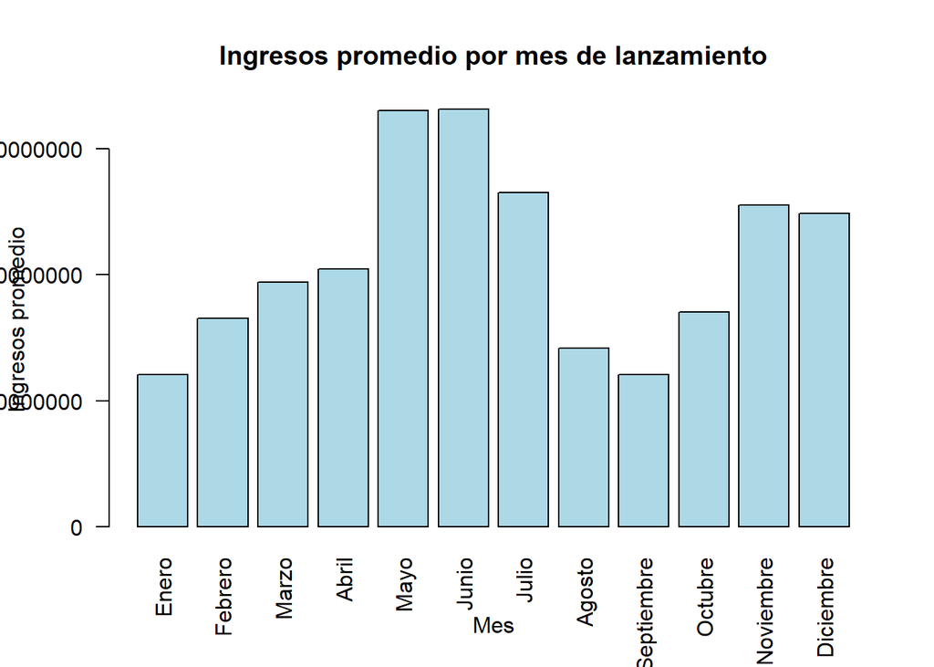

```
## [1] 1656.75
```

A partir del análisis realizado, se observa que los ingresos promedio de las películas varían según el mes de lanzamiento, lo que sugiere que el momento del estreno puede estar asociado con el desempeño económico, aunque no sea el único factor que influye en el éxito comercial. Asimismo, el cálculo de la cantidad promedio de películas lanzadas por mes permite identificar cómo se distribuyen los estrenos a lo largo del año, evidenciando que estos no se concentran de manera uniforme y que podrían responder a estrategias de mercado o a temporadas específicas de mayor demanda.

*14.¿Cómo se correlacionan las calificaciones con el éxito comercial?*

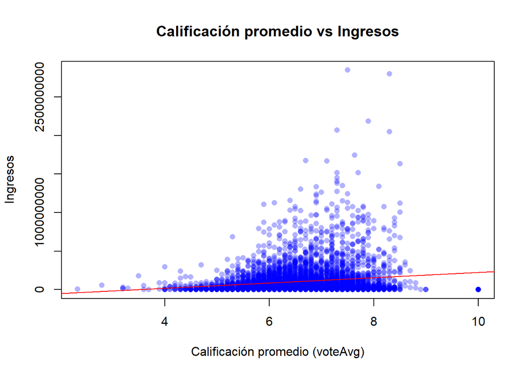

```
## [1] 0.1530356
```

El análisis de la relación entre las calificaciones promedio de las películas y sus ingresos muestra la existencia de una asociación entre ambas variables, aunque esta no es necesariamente fuerte. El diagrama de dispersión y la línea de tendencia permiten observar que películas con mejores calificaciones tienden, en algunos casos, a obtener mayores ingresos, pero también existen películas con buenas calificaciones que no alcanzan un alto éxito comercial. Entonces, si bien la valoración del público puede influir en el desempeño económico, el éxito comercial de una película depende de múltiples factores adicionales como el presupuesto, la estrategia de marketing, el género y el momento de lanzamiento.

*15. ¿Qué estrategias de marketing, como videos promocionales o páginas oficiales, generan mejores resultados?*

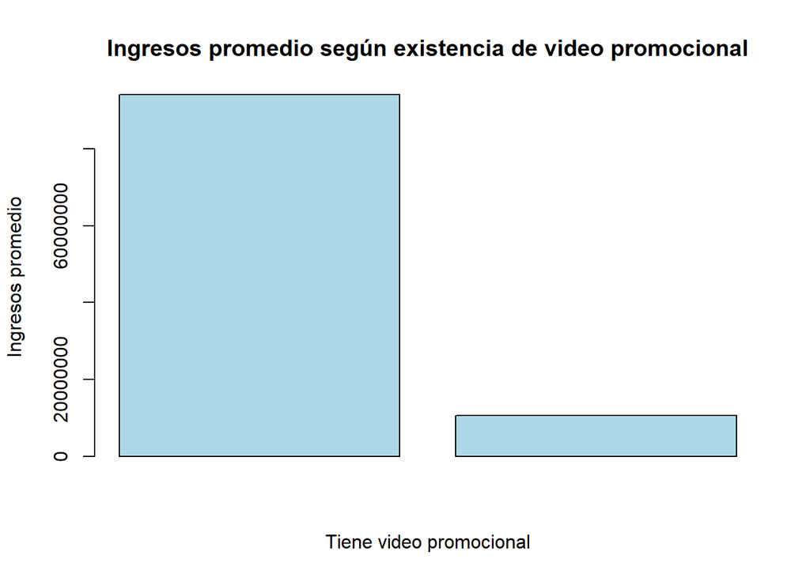

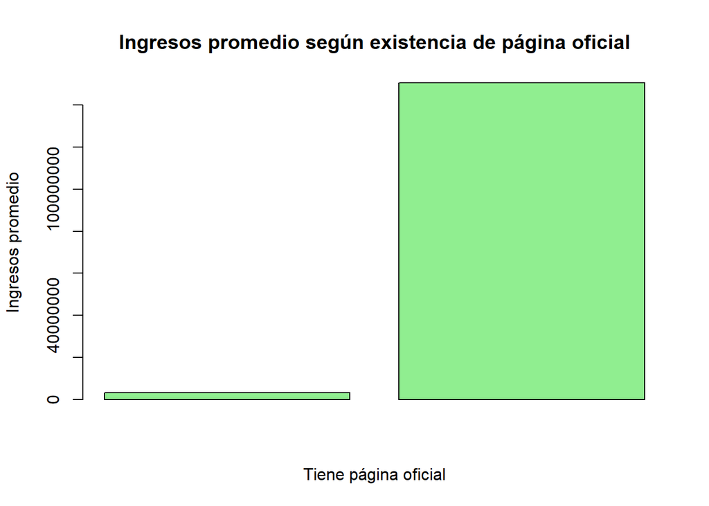

*16.¿La popularidad del elenco está directamente correlacionada con el éxito de taquilla?*

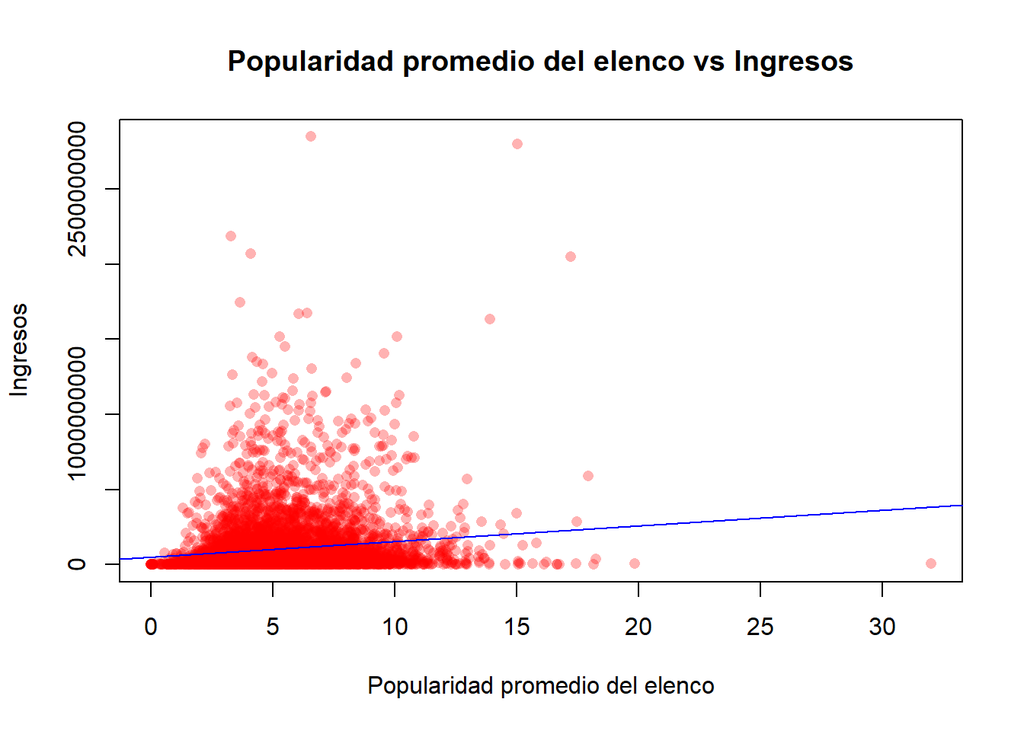

```
## [1] 0.1389274
```

El análisis muestra que existe una relación entre la popularidad promedio del elenco y los ingresos de las películas, aunque esta no es necesariamente fuerte ni directa. Si bien algunas películas con elencos más populares tienden a obtener mayores ingresos, también se observan numerosas excepciones, lo que indica que la popularidad del elenco puede influir en el éxito de taquilla, pero no es el único factor determinante.